# Seaborn

```python
import matplotlib.pyplot as plt
import seaborn as sns
import numpy as np
import pandas as pd
```

## So, things to be learned

### ScatterPlot

### Distributive plot : rug plot, hist or dist plot, kde plot

### Categorical plot : statistical estimations within categories: countplot and barplot

### Categorical plot : Distributions within categories : boxplot, voilinplot, swarmplot, boxenplot

### Comparison plot : jointplot, pair plot

### Seaborn grids

### Matrix plots

# * Scatter Plots

### Scatter plots shows the relationship between two continuous features. eg: price, age, salary, temperature, height, weight.

```python
df = pd.read_csv('Datasets\car data.csv')
df.describe()
```

|  | Year | Selling_Price | Present_Price | Kms_Driven | Owner |
| --- | --- | --- | --- | --- | --- |
| count | 301.000000 | 301.000000 | 301.000000 | 301.000000 | 301.000000 |
| mean | 2013.627907 | 4.661296 | 7.628472 | 36947.205980 | 0.043189 |
| std | 2.891554 | 5.082812 | 8.644115 | 38886.883882 | 0.247915 |
| min | 2003.000000 | 0.100000 | 0.320000 | 500.000000 | 0.000000 |
| 25% | 2012.000000 | 0.900000 | 1.200000 | 15000.000000 | 0.000000 |
| 50% | 2014.000000 | 3.600000 | 6.400000 | 32000.000000 | 0.000000 |
| 75% | 2016.000000 | 6.000000 | 9.900000 | 48767.000000 | 0.000000 |
| max | 2018.000000 | 35.000000 | 92.600000 | 500000.000000 | 3.000000 |

```python
df.head()
```

|  | Car_Name | Year | Selling_Price | Present_Price | Kms_Driven | Fuel_Type | Seller_Type | Transmission | Owner |
| --- | --- | --- | --- | --- | --- | --- | --- | --- | --- |
| 0 | ritz | 2014 | 3.35 | 5.59 | 27000 | Petrol | Dealer | Manual | 0 |
| 1 | sx4 | 2013 | 4.75 | 9.54 | 43000 | Diesel | Dealer | Manual | 0 |
| 2 | ciaz | 2017 | 7.25 | 9.85 | 6900 | Petrol | Dealer | Manual | 0 |
| 3 | wagon r | 2011 | 2.85 | 4.15 | 5200 | Petrol | Dealer | Manual | 0 |
| 4 | swift | 2014 | 4.60 | 6.87 | 42450 | Diesel | Dealer | Manual | 0 |

#### https://matplotlib.org/stable/users/explain/colors/colormaps.html

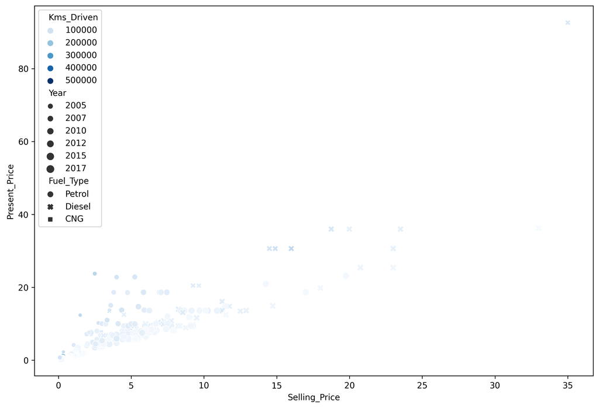

```python
plt.figure(figsize=(12,8), dpi = 300)
sns.scatterplot(x='Selling_Price', y = 'Present_Price', data=df, hue='Kms_Driven',
                style='Fuel_Type',palette='Blues',size='Year',)
```

```python
df.columns
```

```
Index(['Car_Name', 'Year', 'Selling_Price', 'Present_Price', 'Kms_Driven',
       'Fuel_Type', 'Seller_Type', 'Transmission', 'Owner'],
      dtype='object')
```

#### https://www.analyticsvidhya.com/blog/2021/09/how-to-choose-the-right-chart-for-data-visualization/

# * Distributions

### Basically distributive plots are used when we want to analyze any single feature.

```python
df.columns
```

```
Index(['Car_Name', 'Year', 'Selling_Price', 'Present_Price', 'Kms_Driven',
       'Fuel_Type', 'Seller_Type', 'Transmission', 'Owner'],
      dtype='object')
```

### # Rugplot

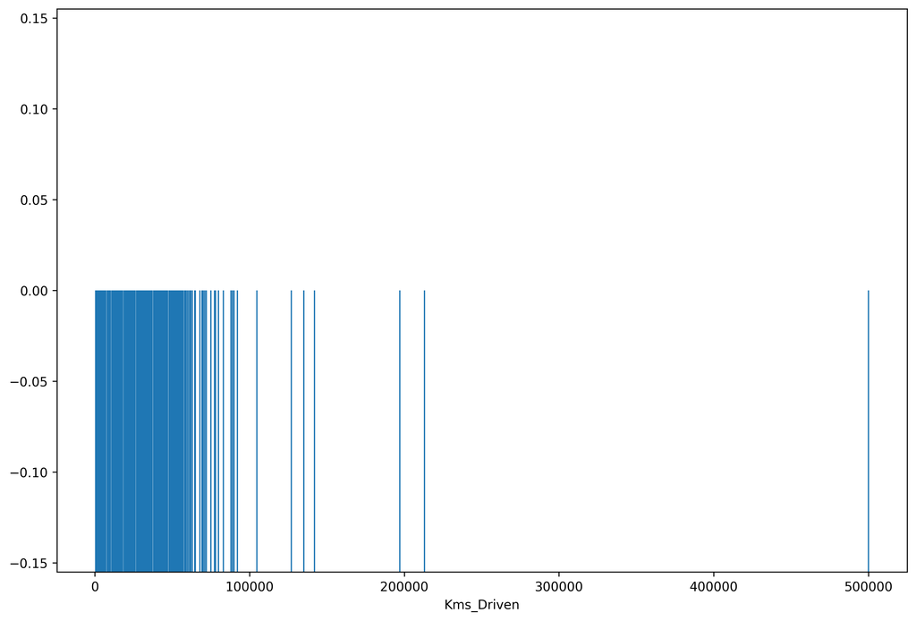

```python
plt.figure(figsize=(12,8), dpi = 300)
sns.rugplot(x = 'Kms_Driven',data = df, height = 0.5)
# generally here in the rugplot we doesn't represent any data on y axis.
```

### # Hist and Dist plot

#### We do not come to know how many ticks marks are there per some segment in the rugplot, as many ticks are coinsiding with each other counting is not possibe. So to overcome this problem we can use Displot or Hist plot

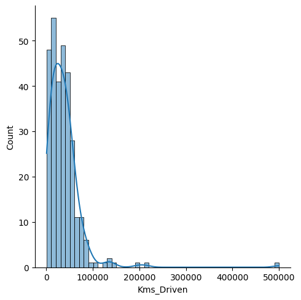

```python
sns.displot(x = 'Kms_Driven', data = df, kde = True )
```

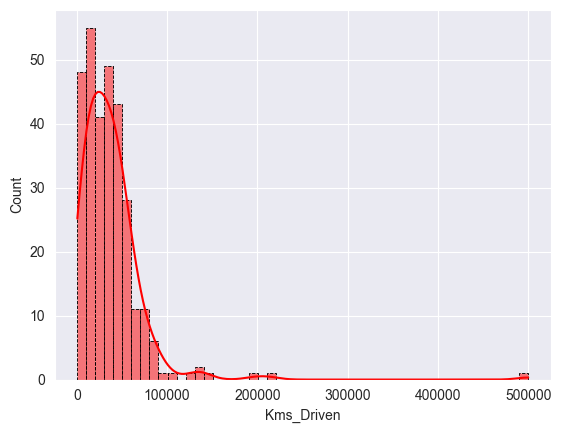

```python
sns.set_style(style='darkgrid')  # here you can give darkgrid, whitegrid, white, ticks
sns.histplot(x = 'Kms_Driven', data = df, kde= True, bins = 50, color = 'red',
              edgecolor = 'black', lw = 10, ls = '--')
```

## # Kde plot (Kernel density estimation)

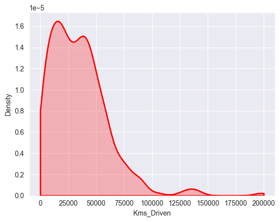

```python
sns.kdeplot(x = 'Kms_Driven', data = df, clip = [0, 200000] ,
            color = 'red', fill=True, lw = 2 , bw_adjust=0.5)
```

#### Well till now in the distribution plots we have worked only on a single feature

#### but there is a 2 dimensional kde plot which can represent two features

```python
df.columns
```

```
Index(['Car_Name', 'Year', 'Selling_Price', 'Present_Price', 'Kms_Driven',
       'Fuel_Type', 'Seller_Type', 'Transmission', 'Owner'],
      dtype='object')
```

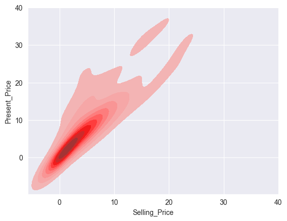

```python
sns.kdeplot(data = df, x = 'Selling_Price', y = 'Present_Price', fill = True,
            color = 'red',clip=[-10,40] )
```

## * Categorical Plot

#### # Statistical Estimation within categories

```python
df.describe()
```

|  | Year | Selling_Price | Present_Price | Kms_Driven | Owner |
| --- | --- | --- | --- | --- | --- |
| count | 301.000000 | 301.000000 | 301.000000 | 301.000000 | 301.000000 |
| mean | 2013.627907 | 4.661296 | 7.628472 | 36947.205980 | 0.043189 |
| std | 2.891554 | 5.082812 | 8.644115 | 38886.883882 | 0.247915 |
| min | 2003.000000 | 0.100000 | 0.320000 | 500.000000 | 0.000000 |
| 25% | 2012.000000 | 0.900000 | 1.200000 | 15000.000000 | 0.000000 |
| 50% | 2014.000000 | 3.600000 | 6.400000 | 32000.000000 | 0.000000 |
| 75% | 2016.000000 | 6.000000 | 9.900000 | 48767.000000 | 0.000000 |
| max | 2018.000000 | 35.000000 | 92.600000 | 500000.000000 | 3.000000 |

```python
df.head()
```

|  | Car_Name | Year | Selling_Price | Present_Price | Kms_Driven | Fuel_Type | Seller_Type | Transmission | Owner |
| --- | --- | --- | --- | --- | --- | --- | --- | --- | --- |
| 0 | ritz | 2014 | 3.35 | 5.59 | 27000 | Petrol | Dealer | Manual | 0 |
| 1 | sx4 | 2013 | 4.75 | 9.54 | 43000 | Diesel | Dealer | Manual | 0 |
| 2 | ciaz | 2017 | 7.25 | 9.85 | 6900 | Petrol | Dealer | Manual | 0 |
| 3 | wagon r | 2011 | 2.85 | 4.15 | 5200 | Petrol | Dealer | Manual | 0 |
| 4 | swift | 2014 | 4.60 | 6.87 | 42450 | Diesel | Dealer | Manual | 0 |

```python
print(df.Seller_Type.value_counts().index)
print(df.Fuel_Type.value_counts().index)
# print(df.Car_Name.value_counts().index)
print(df.Transmission.value_counts().index)

# These type of data can be analyzed by categorical plots
```

```
Index(['Dealer', 'Individual'], dtype='object')
Index(['Petrol', 'Diesel', 'CNG'], dtype='object')
Index(['Manual', 'Automatic'], dtype='object')
```

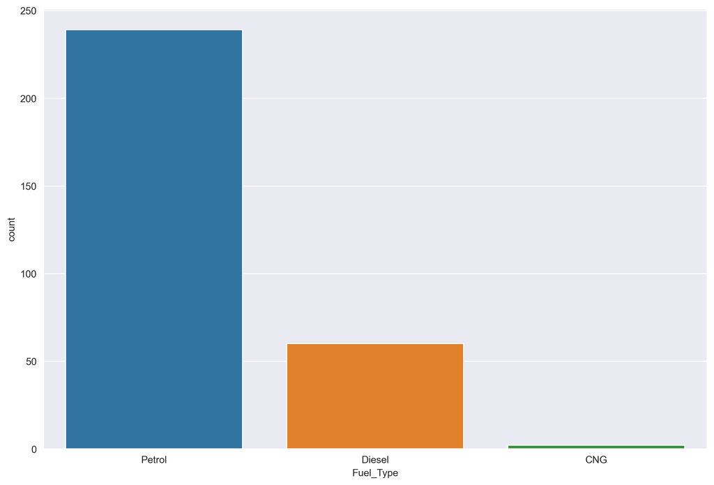

```python
plt.figure(figsize=(12,8), dpi = 300)
sns.countplot(x = 'Fuel_Type', data = df)
# Count plot , it shows the total number of rows per category
```

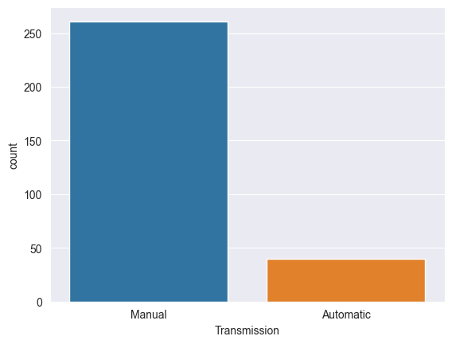

```python
sns.countplot(x = 'Transmission', data = df)
```

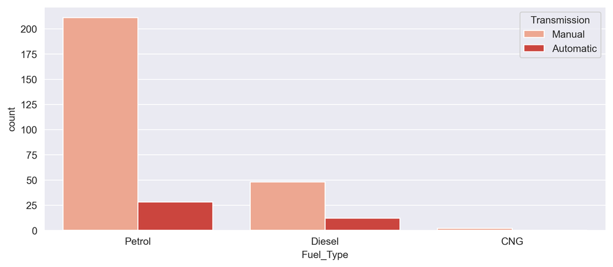

```python
plt.figure(figsize=(10,4), dpi = 300)
sns.countplot(x = 'Fuel_Type', data = df, hue = 'Transmission', palette='Reds')
# So here with the help of hue we can bring another categorical feature into picture.
```

## # Barplot

#### in countplot we saw that y-axis is only used for counting but by using barplot we can expand our visualization by specifying a specific continuous feature for the y-axis

```python
df.columns
```

```
Index(['Car_Name', 'Year', 'Selling_Price', 'Present_Price', 'Kms_Driven',
       'Fuel_Type', 'Seller_Type', 'Transmission', 'Owner'],
      dtype='object')
```

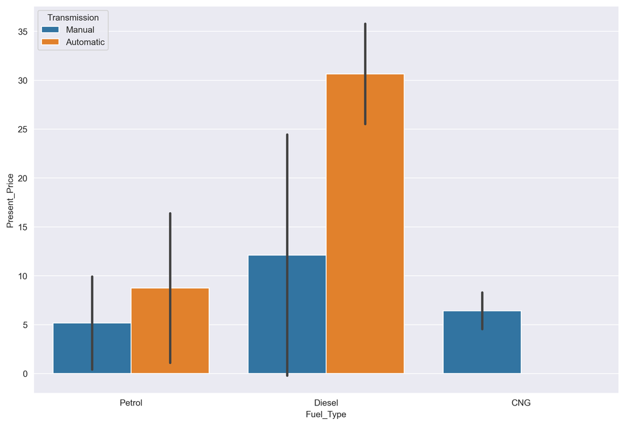

```python
plt.figure(figsize=(12,8), dpi = 300)
sns.barplot(x = 'Fuel_Type', y = 'Present_Price', data = df,
            hue = 'Transmission',estimator=np.mean, errorbar='sd')
```

## # Categorical Plots = Distributions within categories

#### We have saw the distribution plots for a single feature, but what if we want to compare the distributions across categories.

#### for eg., instead of the distributions of everyone's salary, we can compare the distributions of salaries per level of education

#### We will first seperate out each category , then create the distribution visualization

#### Distribution with categories : Types of plots

#### # Boxplot

#### # Violinplot

#### # Swarmplot

#### # Boxenplot

## # Boxplot

```python
df = pd.read_csv('Datasets\car data.csv')
```

```python
df.columns
```

```
Index(['Car_Name', 'Year', 'Selling_Price', 'Present_Price', 'Kms_Driven',
       'Fuel_Type', 'Seller_Type', 'Transmission', 'Owner'],
      dtype='object')
```

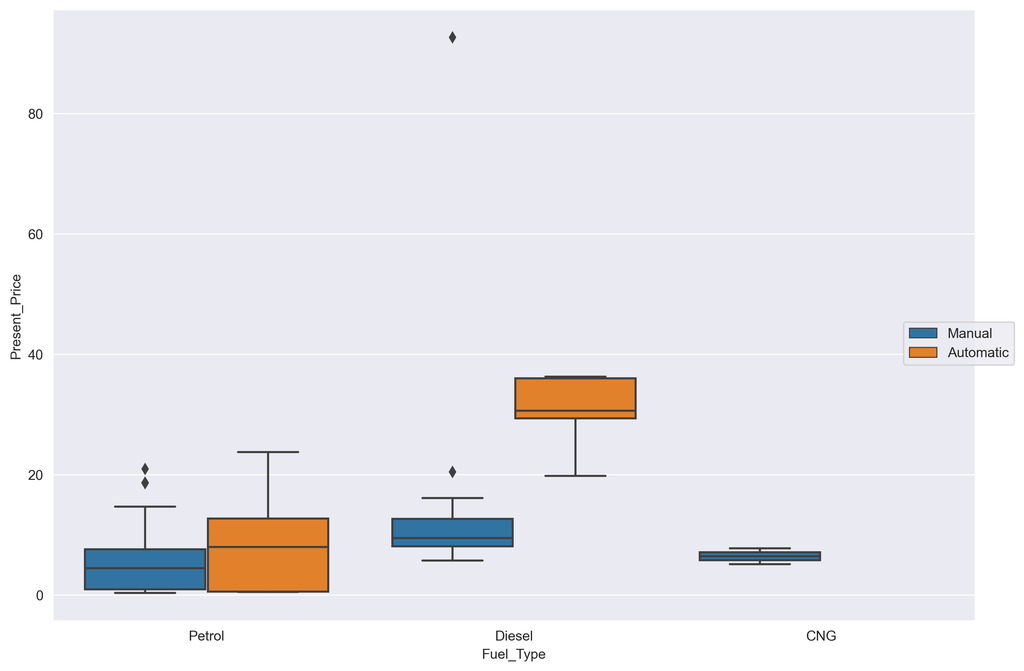

```python
plt.figure(figsize=(12,8),dpi = 300)
sns.boxplot(x = 'Fuel_Type', y = 'Present_Price', data = df,
             hue = 'Transmission')
plt.legend(bbox_to_anchor = (1.05,0.5))
# plt.legend(loc = 0)
```

### # Voilinplot

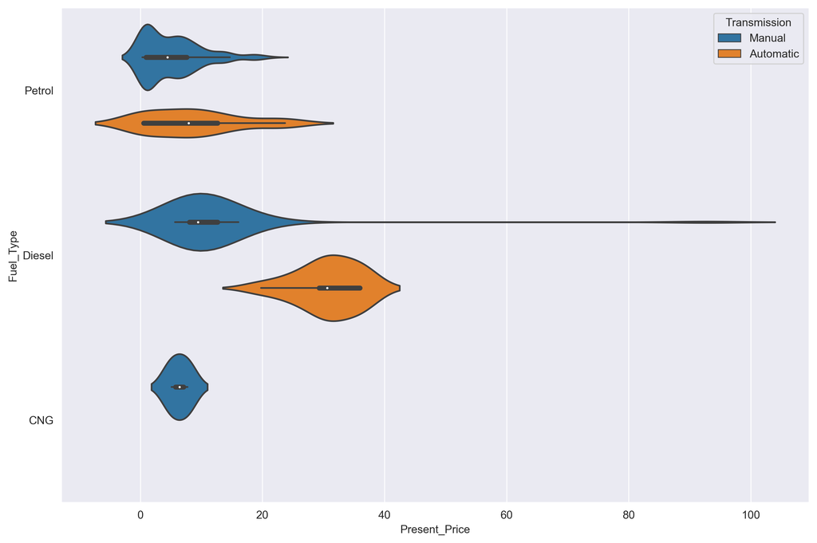

```python
plt.figure(figsize=(12,8) , dpi = 300)
sns.violinplot(x = 'Present_Price', y = 'Fuel_Type', data = df,
                hue = "Transmission")
```

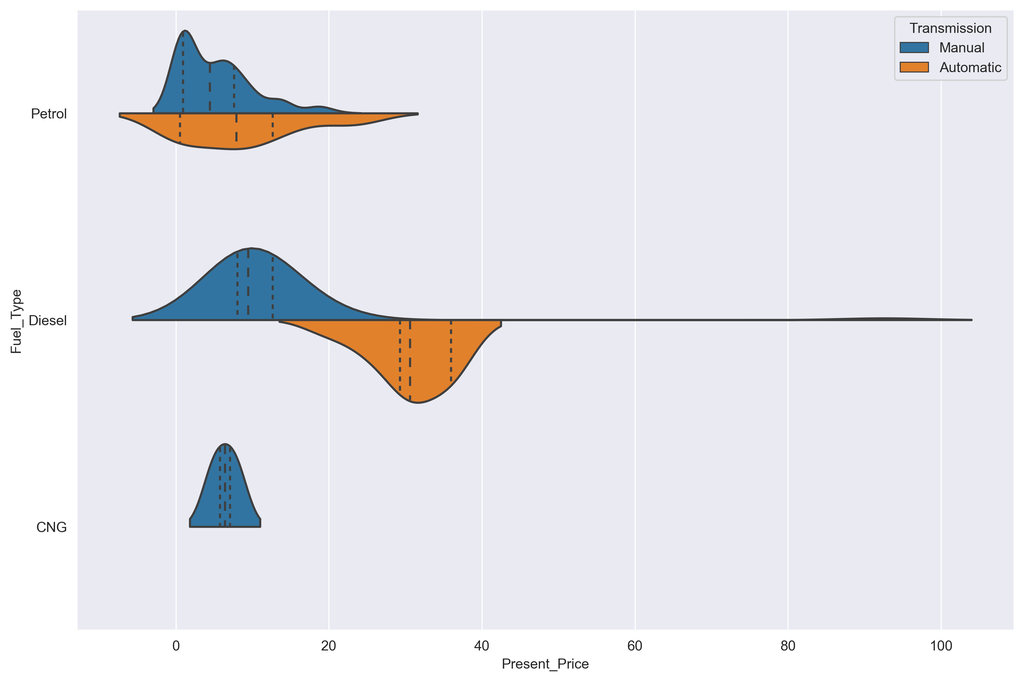

```python
plt.figure(figsize=(12,8) , dpi = 300)
sns.violinplot(x = 'Present_Price', y = 'Fuel_Type', data = df, hue = "Transmission",
               split=True, inner = 'quartiles')
```

### # Swarmplot

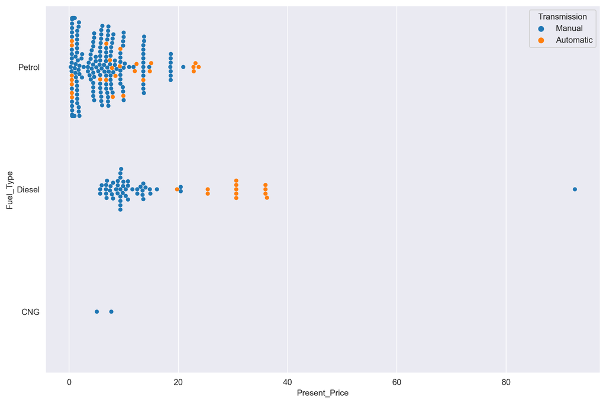

```python
plt.figure(figsize=(12,8),dpi = 300)
sns.swarmplot(x = 'Present_Price', y = 'Fuel_Type', data = df,
               hue = 'Transmission')
```

### # Boxenplot

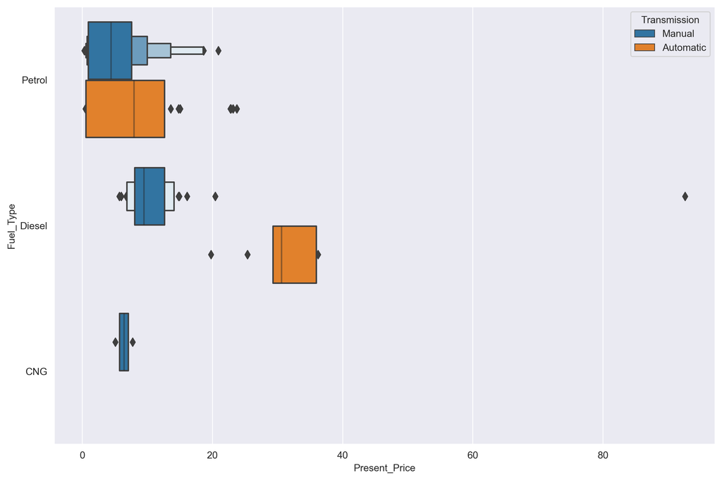

```python
plt.figure(figsize=(12,8), dpi= 300)
sns.boxenplot(x = 'Present_Price', y = 'Fuel_Type', data = df,
               hue = 'Transmission')
```

# * Comparison Plots

### # Joint Plot

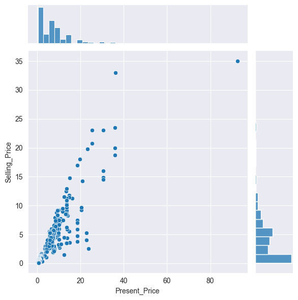

```python
plt.figure(figsize = (12,8), dpi = 300)
sns.jointplot(x = 'Present_Price', y = 'Selling_Price', data = df)
```

#### here we can change the style of graph with the help of kind = ['scatter', 'hist', 'hex', 'kde', 'reg', 'resid'], by default it is set to scatterplot

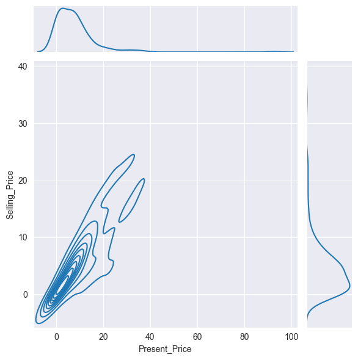

```python
plt.figure(figsize = (12,8), dpi = 300)
sns.jointplot(x = 'Present_Price', y = 'Selling_Price', data = df, kind = 'kde')
```

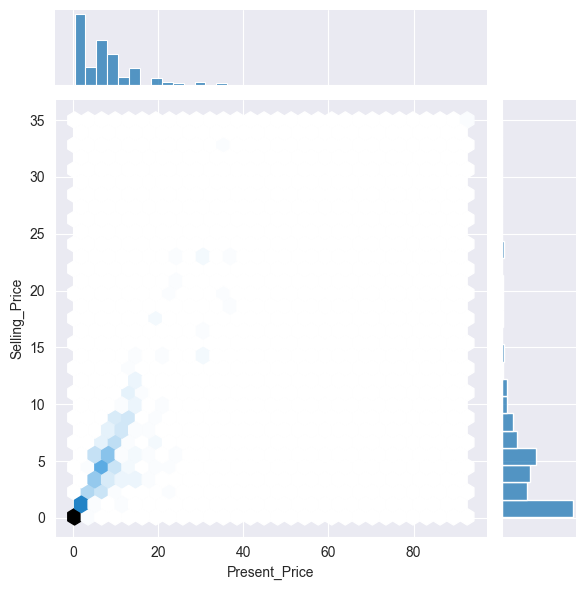

```python
plt.figure(figsize = (12,8), dpi = 300)
sns.jointplot(x = 'Present_Price', y = 'Selling_Price', data = df, kind = 'hex')
```

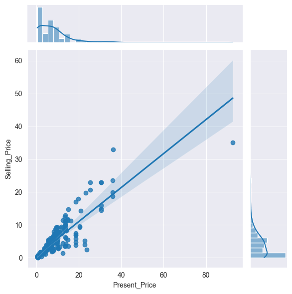

```python
plt.figure(figsize = (12,8), dpi = 300)
sns.jointplot(x = 'Present_Price', y = 'Selling_Price', data = df, kind = 'reg')
```

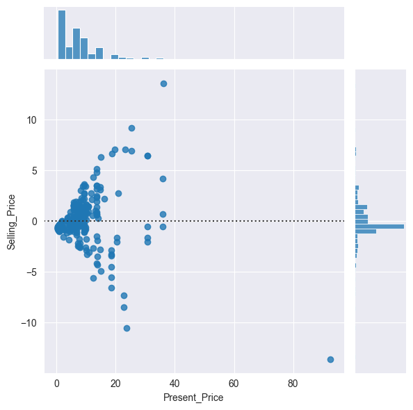

```python
plt.figure(figsize = (12,8), dpi = 300)
sns.jointplot(x = 'Present_Price', y = 'Selling_Price', data = df, kind = 'resid')
```

### # Pairplot

#### all it needs the dataset, rest of all it do on itself. All the numeric data info will be displayed in graphical manner

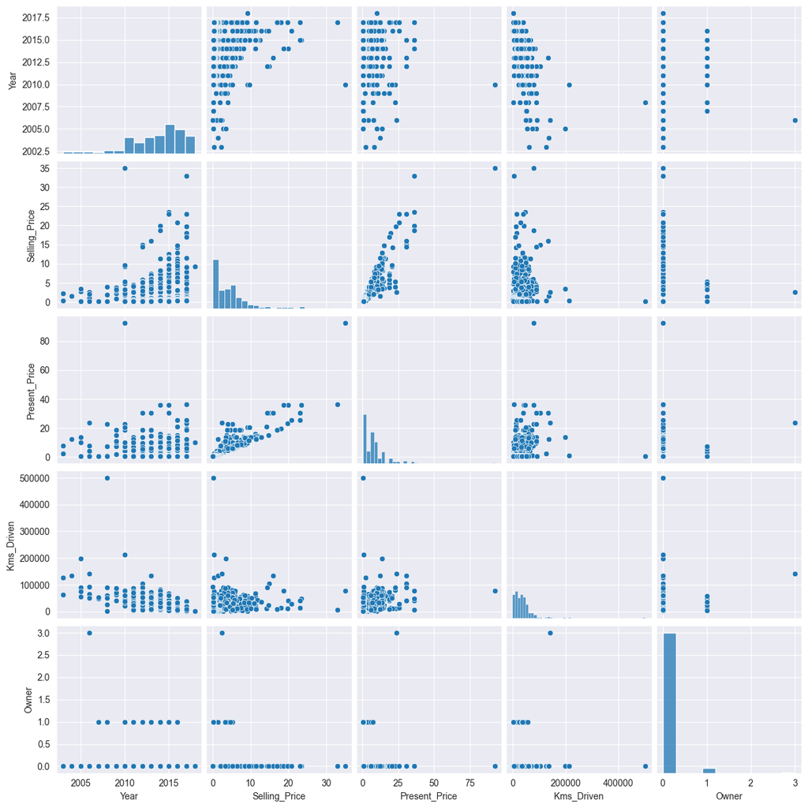

```python
plt.figure(figsize = (12,8), dpi = 300)
sns.pairplot(data = df)
```

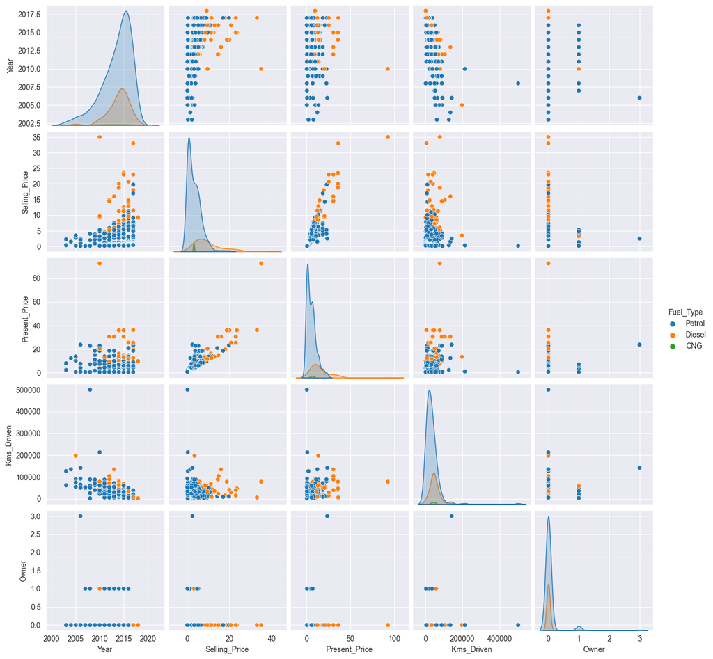

```python
plt.figure(figsize = (12,8), dpi = 300)
sns.pairplot(data = df, hue = "Fuel_Type")
```

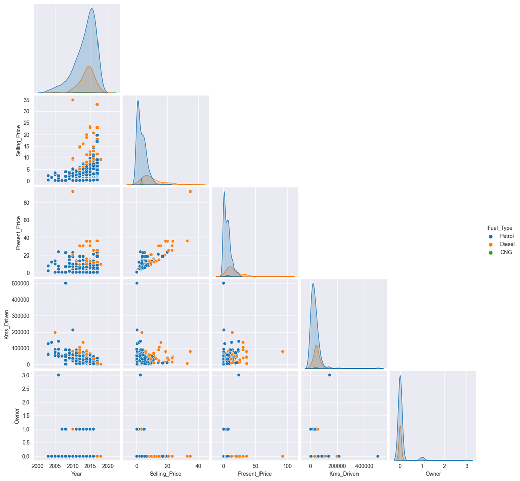

```python
plt.figure(figsize = (12,8), dpi = 300)
sns.pairplot(data = df, hue = "Fuel_Type", corner= True)
```

## * Seaborn Grid

### # Cat plot

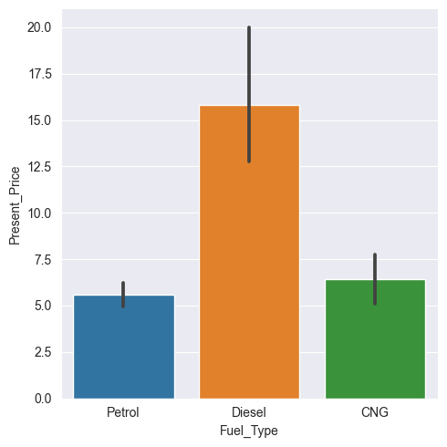

```python
plt.figure(figsize=(12, 8), dpi = 300)
sns.catplot(x = 'Fuel_Type', y = 'Present_Price', data = df,
             kind= 'bar')
# kind can be : ['point', 'bar', 'strip', 'box', 'swarm', 'voilin', 'boxen]
```

```python
df.columns
```

```
Index(['Car_Name', 'Year', 'Selling_Price', 'Present_Price', 'Kms_Driven',
       'Fuel_Type', 'Seller_Type', 'Transmission', 'Owner'],
      dtype='object')
```

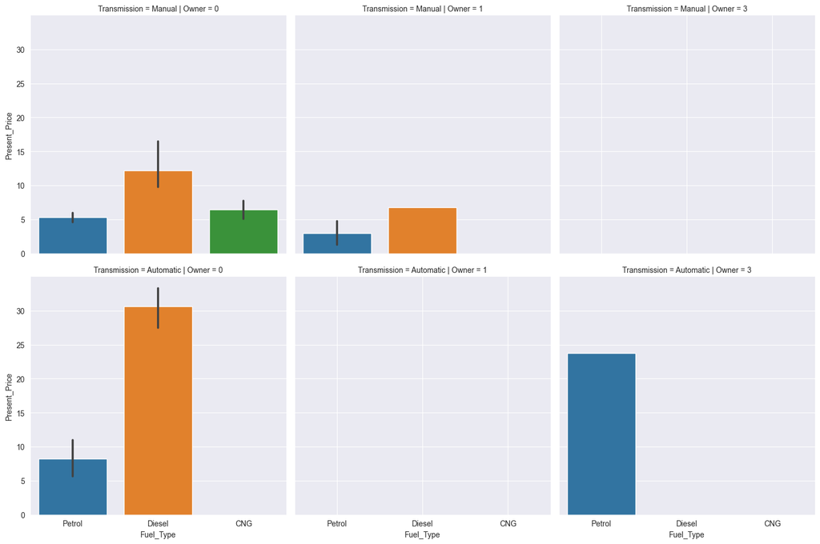

```python
plt.figure(figsize=(12, 8), dpi = 300)
sns.catplot(x = 'Fuel_Type', y = 'Present_Price', data = df, kind= 'bar',
            row = 'Transmission', col = 'Owner')
```

## # Pairgrid

[output not shown]

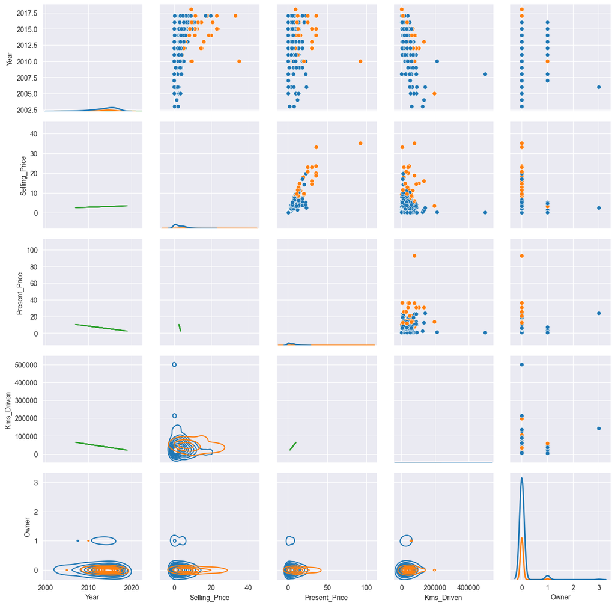

```python
plt.figure(figsize=(12,8), dpi = 300)
g = sns.PairGrid(data = df, hue = 'Fuel_Type', hue_kws={'marker' : ['O','+']} )
g = g.map_upper(sns.scatterplot)
g = g.map_diag(sns.kdeplot, lw = 2)
g = g.map_lower(sns.kdeplot, colors = 'red')
```

## # FacetGrid

[output not shown]

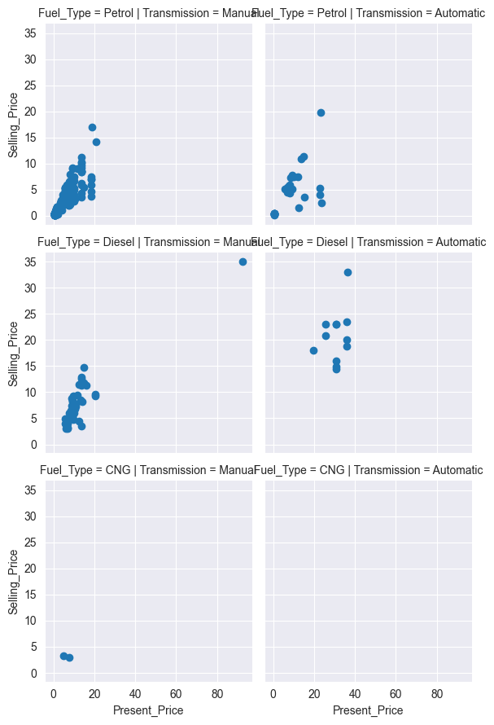

```python
g = sns.FacetGrid(data= df, col = 'Transmission', row = 'Fuel_Type')
g = g.map(plt.scatter, 'Present_Price', 'Selling_Price')
g.add_legend(loc = 0)
plt.subplots_adjust(hspace=0.4, w_space = 0.4)
```

## * MatrixPlot

```python
df = pd.read_csv('Datasets\death-rates-from-air-pollution.csv')
```

```python
df = df[df['Entity'] == 'India']
```

```python
df.head()
```

|  | Entity | Code | Year | Deaths - Air pollution - Sex: Both - Age: Age-standardized (Rate) | Deaths - Household air pollution from solid fuels - Sex: Both - Age: Age-standardized (Rate) | Deaths - Ambient particulate matter pollution - Sex: Both - Age: Age-standardized (Rate) | Deaths - Ambient ozone pollution - Sex: Both - Age: Age-standardized (Rate) |
| --- | --- | --- | --- | --- | --- | --- | --- |
| 2688 | India | IND | 1990 | 211.376738 | 140.873078 | 57.500137 | 25.479616 |
| 2689 | India | IND | 1991 | 209.538102 | 138.362456 | 58.194474 | 25.352090 |
| 2690 | India | IND | 1992 | 207.462594 | 135.459209 | 59.060688 | 25.139187 |
| 2691 | India | IND | 1993 | 201.139283 | 129.963198 | 58.528327 | 24.448590 |
| 2692 | India | IND | 1994 | 195.991024 | 125.203988 | 58.334058 | 23.949792 |

```python
df.set_index('Year')
```

| Year | Entity | Code | Deaths - Air pollution - Sex: Both - Age: Age-standardized (Rate) | Deaths - Household air pollution from solid fuels - Sex: Both - Age: Age-standardized (Rate) | Deaths - Ambient particulate matter pollution - Sex: Both - Age: Age-standardized (Rate) | Deaths - Ambient ozone pollution - Sex: Both - Age: Age-standardized (Rate) |
| --- | --- | --- | --- | --- | --- | --- |
| 1990 | India | IND | 211.376738 | 140.873078 | 57.500137 | 25.479616 |
| 1991 | India | IND | 209.538102 | 138.362456 | 58.194474 | 25.352090 |
| 1992 | India | IND | 207.462594 | 135.459209 | 59.060688 | 25.139187 |
| 1993 | India | IND | 201.139283 | 129.963198 | 58.528327 | 24.448590 |
| 1994 | India | IND | 195.991024 | 125.203988 | 58.334058 | 23.949792 |
| 1995 | India | IND | 190.722434 | 120.460240 | 57.998226 | 23.450432 |
| 1996 | India | IND | 187.942662 | 116.974217 | 58.729165 | 23.234831 |
| 1997 | India | IND | 191.942354 | 118.414786 | 60.901716 | 23.862899 |
| 1998 | India | IND | 189.491894 | 115.778669 | 61.086733 | 23.785558 |
| 1999 | India | IND | 180.311804 | 108.707434 | 59.539222 | 22.608552 |
| 2000 | India | IND | 175.939719 | 104.211662 | 59.897631 | 22.013841 |
| 2001 | India | IND | 172.715934 | 100.486862 | 60.636771 | 21.482037 |
| 2002 | India | IND | 167.611260 | 95.938944 | 60.500931 | 20.669041 |
| 2003 | India | IND | 160.972677 | 90.171411 | 60.121702 | 19.687443 |
| 2004 | India | IND | 151.571503 | 83.108443 | 58.482692 | 18.334055 |
| 2005 | India | IND | 148.706473 | 79.956371 | 59.042924 | 17.747146 |
| 2006 | India | IND | 148.551786 | 78.133715 | 60.685858 | 17.732316 |
| 2007 | India | IND | 148.056272 | 76.241027 | 62.099054 | 17.652383 |
| 2008 | India | IND | 147.324812 | 74.033783 | 63.575443 | 17.569015 |
| 2009 | India | IND | 145.873614 | 71.736019 | 64.453242 | 17.426509 |
| 2010 | India | IND | 145.220560 | 69.913644 | 65.616689 | 17.358088 |
| 2011 | India | IND | 144.743452 | 67.917029 | 67.172223 | 17.241612 |
| 2012 | India | IND | 141.783177 | 67.301761 | 64.774923 | 17.085297 |
| 2013 | India | IND | 140.003470 | 63.056102 | 67.219481 | 17.047079 |
| 2014 | India | IND | 137.597815 | 59.793241 | 67.906896 | 17.130382 |
| 2015 | India | IND | 136.353340 | 56.864057 | 69.485160 | 17.211842 |
| 2016 | India | IND | 134.643938 | 54.362844 | 70.131953 | 17.307470 |
| 2017 | India | IND | 131.994019 | 51.027440 | 70.803435 | 17.240293 |

```python
df.columns
```

```
Index(['Entity', 'Code', 'Year',
       'Deaths - Air pollution - Sex: Both - Age: Age-standardized (Rate)',
       'Deaths - Household air pollution from solid fuels - Sex: Both - Age: Age-standardized (Rate)',
       'Deaths - Ambient particulate matter pollution - Sex: Both - Age: Age-standardized (Rate)',
       'Deaths - Ambient ozone pollution - Sex: Both - Age: Age-standardized (Rate)'],
      dtype='object')
```

```python
df = df.drop(['Code', 'Entity'], axis = 1)
```

```python
df.columns
```

```
Index(['Year',
       'Deaths - Air pollution - Sex: Both - Age: Age-standardized (Rate)',
       'Deaths - Household air pollution from solid fuels - Sex: Both - Age: Age-standardized (Rate)',
       'Deaths - Ambient particulate matter pollution - Sex: Both - Age: Age-standardized (Rate)',
       'Deaths - Ambient ozone pollution - Sex: Both - Age: Age-standardized (Rate)'],
      dtype='object')
```

```python
df = df.rename(columns={
'Deaths - Air pollution - Sex: Both - Age: Age-standardized (Rate)': 'Air pollution',
'Deaths - Household air pollution from solid fuels - Sex: Both - Age: Age-standardized (Rate)': 'Household',
'Deaths - Ambient particulate matter pollution - Sex: Both - Age: Age-standardized (Rate)': 'particulate matter',
'Deaths - Ambient ozone pollution - Sex: Both - Age: Age-standardized (Rate)': 'ozone pollution'})
```

```python
df.head()
```

|  | Year | Air pollution | Household | particulate matter | ozone pollution |
| --- | --- | --- | --- | --- | --- |
| 2688 | 1990 | 211.376738 | 140.873078 | 57.500137 | 25.479616 |
| 2689 | 1991 | 209.538102 | 138.362456 | 58.194474 | 25.352090 |
| 2690 | 1992 | 207.462594 | 135.459209 | 59.060688 | 25.139187 |
| 2691 | 1993 | 201.139283 | 129.963198 | 58.528327 | 24.448590 |
| 2692 | 1994 | 195.991024 | 125.203988 | 58.334058 | 23.949792 |

```python
df = df.set_index('Year')
```

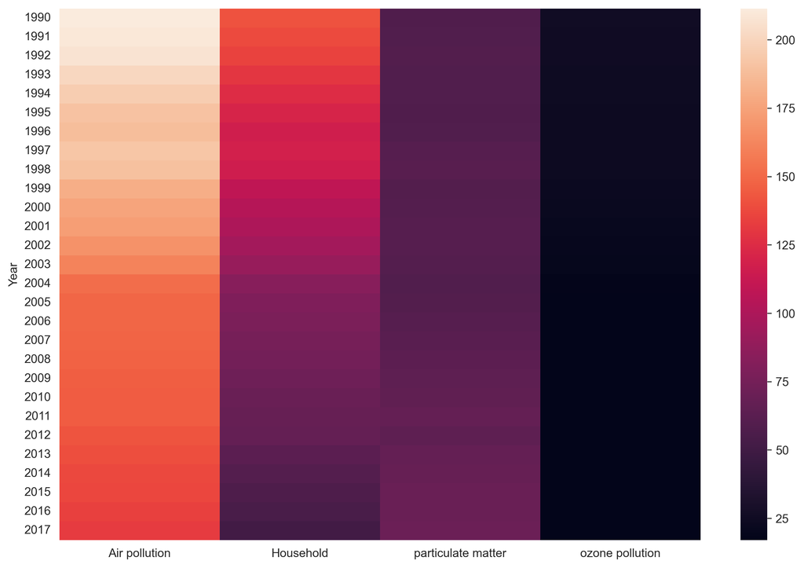

```python
plt.figure(figsize=(12,8), dpi = 300)
sns.heatmap(data = df)
```

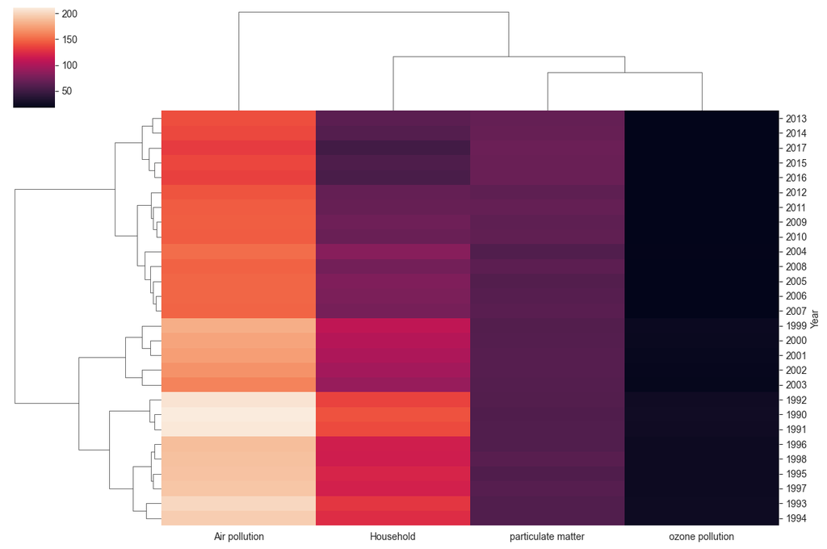

```python
sns.clustermap(data = df, figsize = (12,8))
```

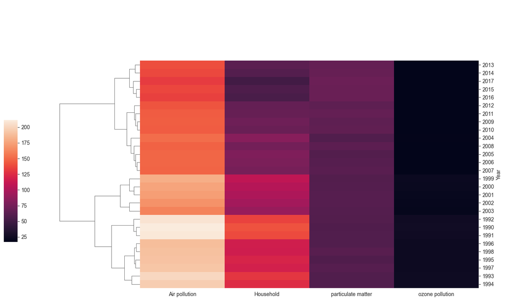

```python
sns.clustermap(data = df, figsize = (12,8), col_cluster=False,
               cbar_pos=(-0.1, 0.2, 0.03, 0.4))
```